# Project 1: Wrangling, Exploration, Visualization

SDS322E

## Data Wrangling, Exploration, Visualization

Astrid Herrera (ach3678)

#### Introduction

The datasets I’m using for this project consist of my best friend’s Spotify data as well as an ephemeris of the sun and moon.

The Spotify data has 4 variables: endTime in which the stream ended in UTC format, artistName which is the creator of the song for each stream, trackName which lists the title of the song or video, and msPlayed which indicates how many miliseconds the track was listened to. The ephemerides provide variables such as day, month, year as well as times in which the sun or moon rose, set, and culminated at their highest point in the sky. Also listed is the distance from the Earth in astronomical units and the zodiac constellation that the sun or moon was located in at the time. Unique to the moon ephemeris is the age of the moon at the time in terms of phase and its brightness in magnitude. Both ephemerides were acquired from the website https://in-the-sky.org/ephemeris.php

I’m interested in combining these datasets because I love astrology and would be interested to see if I can find any pattern in the songs my friend listens to depending on the “zodiac season”. Of course astrology is all speculation and not fact, but I would also love to compare her listening history to the phase of the moon because there are theories that the lunar cycle affects human behavior. It would be really interesting to see the same artists or songs listened to across different zodiac signs, because that would imply that her music taste is consistent and doesn’t vary based on trends or by whatever constellation the Sun or Moon is in.

```r
library(jsonlite)
library(tidyverse)

zariaSpotify <- fromJSON("~/StreamingHistory0.json", flatten = TRUE)
sunData <- read_csv("~/sunephemeris.csv")
moonData <- read_csv("~/moonephemeris.csv")
```

#### Tidying: Reshaping

```r
moonWider <- moonData %>% pivot_wider(names_from = "MoonConstellation",
    values_from = "MoonDistAU")
moonData <- moonWider %>% pivot_longer(cols = c(9:23), names_to = "MoonConstellation",
    values_to = "MoonDistAU", values_drop_na = T)
```

#### Joining/Merging

```r
glimpse(moonData)
```

```
## Rows: 250
## Columns: 10
## $ Year              <chr> "2020", "2020", "2020", "2020", "2020", "2020", "20…
## $ Month             <dbl> 9, 9, 10, 10, 10, 10, 10, 10, 10, 10, 10, 10, 10, 1…
## $ Day               <dbl> 29, 30, 1, 2, 3, 4, 5, 6, 7, 8, 9, 10, 11, 12, 13, …
## $ AgeofMoon         <chr> "12 days", "13 days", "14 days", "15 days", "16 day…
## $ Moonrise          <time> 17:44:00, 18:12:00, 18:36:00, 18:34:00, 18:56:00, …
## $ MoonCulm          <chr> "23:03", "23:45", "0:23", "0:26", "1:07", "1:47", "…
## $ MoonSet           <time> 04:25:00, 05:26:00, 06:26:00, 06:25:00, 07:24:00, …
## $ ApproxMag.        <dbl> -12.5, -12.5, -12.5, -12.5, -12.5, -12.5, -12.4, -1…
## $ MoonConstellation <chr> "Aquarius", "Aquarius", "Pisces", "Cetus", "Pisces"…
## $ MoonDistAU        <dbl> 0.0027, 0.0027, 0.0027, 0.0027, 0.0027, 0.0027, 0.0…
```

```r
glimpse(sunData)
```

```
## Rows: 253
## Columns: 8
## $ Year             <chr> "2020", "2020", "2020", "2020", "2020", "2020", "202…
## $ Month            <dbl> 9, 9, 10, 10, 10, 10, 10, 10, 10, 10, 10, 10, 10, 10…
## $ Day              <dbl> 29, 30, 1, 2, 3, 4, 5, 6, 7, 8, 9, 10, 11, 12, 13, 1…
## $ Sunrise          <time> 06:50:00, 06:49:00, 06:52:00, 06:51:00, 06:54:00, 0…
## $ SunCulm          <time> 12:48:00, 12:48:00, 12:48:00, 12:47:00, 12:47:00, 1…
## $ Sunset           <time> 18:46:00, 18:41:00, 18:40:00, 18:39:00, 18:38:00, 1…
## $ SunDistAu        <dbl> 1.0017, 1.0014, 1.0012, 1.0009, 1.0006, 1.0003, 1.00…
## $ SunConstellation <chr> "Virgo", "Virgo", "Virgo", "Virgo", "Virgo", "Virgo"…
```

```r
glimpse(zariaSpotify)
```

```
## Rows: 10,000
## Columns: 4
## $ endTime    <chr> "2020-09-29 17:55", "2020-10-01 03:40", "2020-10-01 03:45"…
## $ artistName <chr> "Raury", "Anne-Marie", "Janelle Monáe", "Jackson Wang", "K…
## $ trackName  <chr> "God's Whisper", "Do It Right", "Q.U.E.E.N. (feat. Erykah …
## $ msPlayed   <int> 242544, 89136, 310480, 195036, 174644, 0, 175309, 205733, …
```

```r
moonData %>% summarize_all(n_distinct)
```

```
## # A tibble: 1 x 10
##    Year Month   Day AgeofMoon Moonrise MoonCulm MoonSet ApproxMag.
##   <int> <int> <int>     <int>    <int>    <int>   <int>      <int>
## 1     2    10    31        30      228      223     223         58
## # … with 2 more variables: MoonConstellation <int>, MoonDistAU <int>
```

```r
sunData %>% summarize_all(n_distinct)
```

```
## # A tibble: 1 x 8
##    Year Month   Day Sunrise SunCulm Sunset SunDistAu SunConstellation
##   <int> <int> <int>   <int>   <int>  <int>     <int>            <int>
## 1     5    11    32      83      55    120       173               11
```

```r
zariaSpotify %>% summarize_all(n_distinct)
```

```
##   endTime artistName trackName msPlayed
## 1    8037        829      2020     4748
```

```r
zariaSpotify <- zariaSpotify %>% separate(endTime, into = c("Date",
    "Endtime"), sep = " ") %>% separate(Date, into = c("Year",
    "Month", "Day")) %>% mutate(Month = as.numeric(Month))

ephemeris <- inner_join(moonData, sunData, by = c(Year = "Year",
    Month = "Month", Day = "Day")) %>% mutate(Day = as.character(Day))
glimpse(ephemeris)
```

```
## Rows: 250
## Columns: 15
## $ Year              <chr> "2020", "2020", "2020", "2020", "2020", "2020", "20…
## $ Month             <dbl> 9, 9, 10, 10, 10, 10, 10, 10, 10, 10, 10, 10, 10, 1…
## $ Day               <chr> "29", "30", "1", "2", "3", "4", "5", "6", "7", "8",…
## $ AgeofMoon         <chr> "12 days", "13 days", "14 days", "15 days", "16 day…
## $ Moonrise          <time> 17:44:00, 18:12:00, 18:36:00, 18:34:00, 18:56:00, …
## $ MoonCulm          <chr> "23:03", "23:45", "0:23", "0:26", "1:07", "1:47", "…
## $ MoonSet           <time> 04:25:00, 05:26:00, 06:26:00, 06:25:00, 07:24:00, …
## $ ApproxMag.        <dbl> -12.5, -12.5, -12.5, -12.5, -12.5, -12.5, -12.4, -1…
## $ MoonConstellation <chr> "Aquarius", "Aquarius", "Pisces", "Cetus", "Pisces"…
## $ MoonDistAU        <dbl> 0.0027, 0.0027, 0.0027, 0.0027, 0.0027, 0.0027, 0.0…
## $ Sunrise           <time> 06:50:00, 06:49:00, 06:52:00, 06:51:00, 06:54:00, …
## $ SunCulm           <time> 12:48:00, 12:48:00, 12:48:00, 12:47:00, 12:47:00, …
## $ Sunset            <time> 18:46:00, 18:41:00, 18:40:00, 18:39:00, 18:38:00, …
## $ SunDistAu         <dbl> 1.0017, 1.0014, 1.0012, 1.0009, 1.0006, 1.0003, 1.0…
## $ SunConstellation  <chr> "Virgo", "Virgo", "Virgo", "Virgo", "Virgo", "Virgo…
```

```r
joined <- left_join(ephemeris, zariaSpotify, by = c(Year = "Year",
    Month = "Month", Day = "Day"))
ephemeris %>% summarize_all(n_distinct)
```

```
## # A tibble: 1 x 15
##    Year Month   Day AgeofMoon Moonrise MoonCulm MoonSet ApproxMag.
##   <int> <int> <int>     <int>    <int>    <int>   <int>      <int>
## 1     2    10    31        30      228      223     223         58
## # … with 7 more variables: MoonConstellation <int>, MoonDistAU <int>,
## #   Sunrise <int>, SunCulm <int>, Sunset <int>, SunDistAu <int>,
## #   SunConstellation <int>
```

```r
joined %>% summarize_all(n_distinct)
```

```
## # A tibble: 1 x 19
##    Year Month   Day AgeofMoon Moonrise MoonCulm MoonSet ApproxMag.
##   <int> <int> <int>     <int>    <int>    <int>   <int>      <int>
## 1     2    10    31        30      228      223     223         58
## # … with 11 more variables: MoonConstellation <int>, MoonDistAU <int>,
## #   Sunrise <int>, SunCulm <int>, Sunset <int>, SunDistAu <int>,
## #   SunConstellation <int>, Endtime <int>, artistName <int>, trackName <int>,
## #   msPlayed <int>
```

```r
glimpse(joined)
```

```
## Rows: 7,094
## Columns: 19
## $ Year              <chr> "2020", "2020", "2020", "2020", "2020", "2020", "20…
## $ Month             <dbl> 9, 9, 10, 10, 10, 10, 10, 10, 10, 10, 10, 10, 10, 1…
## $ Day               <chr> "29", "30", "1", "2", "3", "4", "5", "6", "7", "8",…
## $ AgeofMoon         <chr> "12 days", "13 days", "14 days", "15 days", "16 day…
## $ Moonrise          <time> 17:44:00, 18:12:00, 18:36:00, 18:34:00, 18:56:00, …
## $ MoonCulm          <chr> "23:03", "23:45", "0:23", "0:26", "1:07", "1:47", "…
## $ MoonSet           <time> 04:25:00, 05:26:00, 06:26:00, 06:25:00, 07:24:00, …
## $ ApproxMag.        <dbl> -12.5, -12.5, -12.5, -12.5, -12.5, -12.5, -12.4, -1…
## $ MoonConstellation <chr> "Aquarius", "Aquarius", "Pisces", "Cetus", "Pisces"…
## $ MoonDistAU        <dbl> 0.0027, 0.0027, 0.0027, 0.0027, 0.0027, 0.0027, 0.0…
## $ Sunrise           <time> 06:50:00, 06:49:00, 06:52:00, 06:51:00, 06:54:00, …
## $ SunCulm           <time> 12:48:00, 12:48:00, 12:48:00, 12:47:00, 12:47:00, …
## $ Sunset            <time> 18:46:00, 18:41:00, 18:40:00, 18:39:00, 18:38:00, …
## $ SunDistAu         <dbl> 1.0017, 1.0014, 1.0012, 1.0009, 1.0006, 1.0003, 1.0…
## $ SunConstellation  <chr> "Virgo", "Virgo", "Virgo", "Virgo", "Virgo", "Virgo…
## $ Endtime           <chr> "17:55", NA, NA, NA, NA, NA, NA, NA, NA, NA, NA, "0…
## $ artistName        <chr> "Raury", NA, NA, NA, NA, NA, NA, NA, NA, NA, NA, "L…
## $ trackName         <chr> "God's Whisper", NA, NA, NA, NA, NA, NA, NA, NA, NA…
## $ msPlayed          <int> 242544, NA, NA, NA, NA, NA, NA, NA, NA, NA, NA, 149…
```

The moon ephemeris dataset contained 250 rows and 10 columns.The Sun ephemeris dataset contained 253 rows and 8 columns, and the Spotify dataset contained 10,000 rows and 4 columns.

The date and song end time from the Spotify data was first separated into two variables, and the date was separated into month, day, and year variables so that it could be easily joined with the ephemeris data.

#### Wrangling

```r
# using mutate and str_extract to create phase variable, also
# to recode month variable
joined <- joined %>% mutate(AgeofMoon = as.numeric(str_extract(AgeofMoon,
    "[0-9]+"))) %>% mutate(MoonPhase = case_when(AgeofMoon ==
    30 | AgeofMoon == 1 ~ "New Moon", AgeofMoon == 15 ~ "Full Moon",
    AgeofMoon == 8 ~ "First Quarter", AgeofMoon == 22 ~ "Last Quarter",
    AgeofMoon <= 7 & 2 <= AgeofMoon ~ "Waxing Crescent", AgeofMoon <=
        14 & 9 <= AgeofMoon ~ "Waxing Gibbous", AgeofMoon <=
        21 & 16 <= AgeofMoon ~ "Waning Gibbous", AgeofMoon <=
        29 & 23 <= AgeofMoon ~ "Waning Crescent"))

# replacing sidereal constellations to tropical
joined <- joined %>% mutate(MoonConstellation = str_replace(MoonConstellation,
    "Ophiuchus", "Sagittarius")) %>% mutate(SunConstellation = str_replace(SunConstellation,
    "Ophiuchus", "Sagittarius")) %>% mutate(MoonConstellation = str_replace(MoonConstellation,
    "Cetus", "Aries")) %>% mutate(SunConstellation = str_replace(SunConstellation,
    "Cetus", "Aries"))

# changing msPlayed to minutesPlayed
joined <- joined %>% mutate(minutesPlayed = msPlayed/60000)

# using select to get rid of numeric variables that aren't of
# interest
joined <- joined %>% select(-MoonCulm, -SunCulm, -msPlayed)

## count NAs
joined %>% summarize_all(function(x) sum(is.na(x)))
```

```
## # A tibble: 1 x 18
##    Year Month   Day AgeofMoon Moonrise MoonSet ApproxMag. MoonConstellati…
##   <int> <int> <int>     <int>    <int>   <int>      <int>            <int>
## 1     0     0     0         0        0       0          0                0
## # … with 10 more variables: MoonDistAU <int>, Sunrise <int>, Sunset <int>,
## #   SunDistAu <int>, SunConstellation <int>, Endtime <int>, artistName <int>,
## #   trackName <int>, MoonPhase <int>, minutesPlayed <int>
```

```r
# filter out skipped songs
joined <- joined %>% filter(minutesPlayed > 0)

# exploring what artists were most frequently listened to the
# most during sagittarius season
joined %>% filter(SunConstellation == "Sagittarius") %>% group_by(artistName) %>%
    summarize(n = n()) %>% arrange(desc(n))
```

```
## # A tibble: 395 x 2
##    artistName         n
##    <chr>          <int>
##  1 Chase Atlantic   216
##  2 GOT7              86
##  3 BTS               83
##  4 Jessi             76
##  5 Ariana Grande     55
##  6 ITZY              55
##  7 Toby Fox          54
##  8 Glass Animals     51
##  9 Mystery Skulls    47
## 10 Slushii           45
## # … with 385 more rows
```

```r
# exploring which moon phase had the highest average song
# listening time
joined %>% group_by(MoonPhase) %>% summarize(avgSongListening = mean(minutesPlayed)) %>%
    arrange(desc(avgSongListening))
```

```
## # A tibble: 7 x 2
##   MoonPhase       avgSongListening
##   <chr>                      <dbl>
## 1 Waxing Gibbous              2.74
## 2 Waning Gibbous              2.67
## 3 Waxing Crescent             2.57
## 4 First Quarter               2.53
## 5 Waning Crescent             2.51
## 6 New Moon                    2.27
## 7 Full Moon                   2.11
```

```r
# creating summary statistics all numerics
joined %>% summarize_if(is.numeric, list(Min = min, Max = max),
    na.rm = T)
```

```
## # A tibble: 1 x 12
##   Month_Min AgeofMoon_Min ApproxMag._Min MoonDistAU_Min SunDistAu_Min
##       <dbl>         <dbl>          <dbl>          <dbl>         <dbl>
## 1         1             1          -12.7        0.00240         0.983
## # … with 7 more variables: minutesPlayed_Min <dbl>, Month_Max <dbl>,
## #   AgeofMoon_Max <dbl>, ApproxMag._Max <dbl>, MoonDistAU_Max <dbl>,
## #   SunDistAu_Max <dbl>, minutesPlayed_Max <dbl>
```

```r
joined %>% summarize_if(is.numeric, list(Avg = mean, Sd = sd),
    na.rm = T)
```

```
## # A tibble: 1 x 12
##   Month_Avg AgeofMoon_Avg ApproxMag._Avg MoonDistAU_Avg SunDistAu_Avg
##       <dbl>         <dbl>          <dbl>          <dbl>         <dbl>
## 1      7.46          13.2          -10.7        0.00257         0.988
## # … with 7 more variables: minutesPlayed_Avg <dbl>, Month_Sd <dbl>,
## #   AgeofMoon_Sd <dbl>, ApproxMag._Sd <dbl>, MoonDistAU_Sd <dbl>,
## #   SunDistAu_Sd <dbl>, minutesPlayed_Sd <dbl>
```

```r
joined %>% summarize_if(is.numeric, list(Unique = n_distinct))
```

```
## # A tibble: 1 x 6
##   Month_Unique AgeofMoon_Unique ApproxMag._Uniq… MoonDistAU_Uniq…
##          <int>            <int>            <int>            <int>
## 1            6               26               46                4
## # … with 2 more variables: SunDistAu_Unique <int>, minutesPlayed_Unique <int>
```

```r
## counts for categoricals
joined %>% group_by(SunConstellation) %>% summarize(SunConstFreq = n()) %>%
    arrange(desc(SunConstFreq))
```

```
## # A tibble: 5 x 2
##   SunConstellation SunConstFreq
##   <chr>                   <int>
## 1 Sagittarius              2615
## 2 Virgo                    1458
## 3 Capricornus              1261
## 4 Libra                     830
## 5 Scorpius                  628
```

```r
joined %>% group_by(MoonConstellation) %>% summarize(MoonConstFreq = n()) %>%
    arrange(desc(MoonConstFreq))
```

```
## # A tibble: 12 x 2
##    MoonConstellation MoonConstFreq
##    <chr>                     <int>
##  1 Sagittarius                1219
##  2 Aquarius                    911
##  3 Capricornus                 772
##  4 Aries                       712
##  5 Taurus                      618
##  6 Pisces                      518
##  7 Virgo                       508
##  8 Libra                       445
##  9 Gemini                      325
## 10 Cancer                      322
## 11 Leo                         287
## 12 Scorpius                    155
```

```r
joined %>% group_by(artistName) %>% summarize(ArtistFreq = n()) %>%
    arrange(desc(ArtistFreq))
```

```
## # A tibble: 743 x 2
##    artistName          ArtistFreq
##    <chr>                    <int>
##  1 Mystery Skulls             345
##  2 Chase Atlantic             263
##  3 BTS                        198
##  4 GOT7                       186
##  5 Toby Fox                   180
##  6 Ariana Grande              149
##  7 Panic! At The Disco        107
##  8 K/DA                        93
##  9 Jessi                       89
## 10 たかやん                    87
## # … with 733 more rows
```

```r
joined %>% group_by(trackName) %>% summarize(SongFreq = n()) %>%
    arrange(desc(SongFreq))
```

```
## # A tibble: 1,694 x 2
##    trackName                      SongFreq
##    <chr>                             <int>
##  1 NUNU NANA                            86
##  2 The Future                           56
##  3 Dope                                 46
##  4 Hellbent (feat. Snowblood)           44
##  5 Round & Round                        44
##  6 Galaxy                               42
##  7 Q.U.E.E.N. (feat. Erykah Badu)       41
##  8 Whatever It Takes                    41
##  9 Hymn for the Weekend                 40
## 10 No Care                              39
## # … with 1,684 more rows
```

```r
joined %>% group_by(MoonPhase) %>% summarize(PhaseFreq = n()) %>%
    arrange(desc(PhaseFreq))
```

```
## # A tibble: 7 x 2
##   MoonPhase       PhaseFreq
##   <chr>               <int>
## 1 Waxing Crescent      2042
## 2 Waxing Gibbous       1795
## 3 Waning Crescent      1646
## 4 New Moon              611
## 5 First Quarter         271
## 6 Waning Gibbous        248
## 7 Full Moon             179
```

```r
# grouping summaries what was average, standard deviation,
# and total listening time for both every sun and moon
# placement combination?
joined %>% group_by(SunConstellation, MoonConstellation) %>%
    summarize(AvgSongListening = mean(minutesPlayed, na.rm = T),
        SDSongListening = sd(minutesPlayed, na.rm = T), TotalListening = sum(minutesPlayed)) %>%
    arrange((SunConstellation)) %>% knitr::kable()
```

| SunConstellation | MoonConstellation | AvgSongListening | SDSongListening | TotalListening |
| --- | --- | --- | --- | --- |
| Capricornus | Aquarius | 2.727580 | 1.5598431 | 556.426333 |
| Capricornus | Aries | 2.777207 | 1.4278542 | 263.834717 |
| Capricornus | Cancer | 2.441160 | 1.5524398 | 263.645233 |
| Capricornus | Capricornus | 2.142026 | 1.7321323 | 376.996650 |
| Capricornus | Gemini | 2.503681 | 2.2625126 | 375.552217 |
| Capricornus | Leo | 2.577503 | 1.6053214 | 213.932733 |
| Capricornus | Pisces | 2.361653 | 1.6164970 | 337.716417 |
| Capricornus | Taurus | 4.749663 | 33.3541835 | 1434.398233 |
| Libra | Aquarius | 2.582101 | 1.5351917 | 423.464517 |
| Libra | Capricornus | 2.546766 | 1.3662797 | 300.518417 |
| Libra | Leo | 3.193521 | 0.9607344 | 153.289000 |
| Libra | Libra | 1.590841 | 1.7491581 | 109.768050 |
| Libra | Sagittarius | 1.926815 | 1.7635824 | 400.777600 |
| Libra | Scorpius | 1.476905 | 1.7403792 | 42.830233 |
| Libra | Virgo | 2.789016 | 1.5135329 | 541.069033 |
| Sagittarius | Aquarius | 2.910887 | 1.6385232 | 983.879650 |
| Sagittarius | Aries | 2.472997 | 1.5102348 | 880.387100 |
| Sagittarius | Capricornus | 2.659684 | 1.6407443 | 880.355483 |
| Sagittarius | Gemini | 2.783484 | 1.4804082 | 328.451067 |
| Sagittarius | Libra | 2.368551 | 1.6143724 | 386.073850 |
| Sagittarius | Pisces | 2.962150 | 1.3433403 | 382.117300 |
| Sagittarius | Sagittarius | 2.421218 | 1.5614043 | 1430.940100 |
| Sagittarius | Scorpius | 3.007573 | 1.4510793 | 378.954267 |
| Sagittarius | Taurus | 2.618123 | 1.4456419 | 827.326900 |
| Sagittarius | Virgo | 2.511983 | 1.5258086 | 369.261483 |
| Scorpius | Aquarius | 2.104847 | 1.6440873 | 277.839783 |
| Scorpius | Aries | 1.906309 | 1.6074912 | 482.296250 |
| Scorpius | Pisces | 1.771251 | 1.7459056 | 430.414067 |
| Virgo | Aquarius | 2.066811 | 1.5081915 | 150.877183 |
| Virgo | Aries | 1.676652 | 1.7175067 | 13.413217 |
| Virgo | Cancer | 2.039708 | 1.5026298 | 436.497533 |
| Virgo | Capricornus | 2.218349 | 1.5207125 | 326.097250 |
| Virgo | Gemini | 2.562122 | 1.4230436 | 146.040950 |
| Virgo | Leo | 2.734021 | 1.4608836 | 426.507233 |
| Virgo | Libra | 2.550244 | 2.7850750 | 543.201950 |
| Virgo | Pisces | 1.854444 | 1.5525199 | 5.563333 |
| Virgo | Sagittarius | 2.675056 | 1.5541610 | 1123.523400 |
| Virgo | Virgo | 2.478593 | 1.5142615 | 413.924967 |

```r
## what was average, min, max, and total listening time at
## each moon phase?
joined %>% group_by(MoonPhase) %>% summarize(AvgSongListening = mean(minutesPlayed,
    na.rm = T), MinSongListening = min(minutesPlayed, na.rm = T),
    MaxSongListening = max(minutesPlayed, na.rm = T), TotalListening = sum(minutesPlayed)) %>%
    arrange(desc(AvgSongListening)) %>% knitr::kable()
```

| MoonPhase | AvgSongListening | MinSongListening | MaxSongListening | TotalListening |
| --- | --- | --- | --- | --- |
| Waxing Gibbous | 2.740784 | 0.0001667 | 580.610967 | 4919.7076 |
| Waning Gibbous | 2.667702 | 0.0005667 | 7.169750 | 661.5900 |
| Waxing Crescent | 2.570499 | 0.0003333 | 35.925333 | 5248.9583 |
| First Quarter | 2.529952 | 0.0081167 | 7.574967 | 685.6169 |
| Waning Crescent | 2.513517 | 0.0000500 | 7.957850 | 4137.2496 |
| New Moon | 2.269386 | 0.0003833 | 7.125817 | 1386.5950 |
| Full Moon | 2.114225 | 0.0003500 | 6.197667 | 378.4463 |

```r
## who was the most frequently listened to artist during a
## full moon?
joined %>% filter(MoonPhase == "Full Moon") %>% group_by(artistName) %>%
    summarize(n = n()) %>% arrange(desc(n))
```

```
## # A tibble: 78 x 2
##    artistName                n
##    <chr>                 <int>
##  1 Toby Fox                 54
##  2 Ariana Grande            10
##  3 Everything Everything     5
##  4 Jessi                     5
##  5 Fall Out Boy              4
##  6 Janelle Monáe             3
##  7 Papa Roach                3
##  8 SuperM                    3
##  9 TWICE                     3
## 10 Waterparks                3
## # … with 68 more rows
```

```r
glimpse(joined)
```

```
## Rows: 6,792
## Columns: 18
## $ Year              <chr> "2020", "2020", "2020", "2020", "2020", "2020", "20…
## $ Month             <dbl> 9, 10, 10, 10, 10, 10, 10, 10, 10, 10, 10, 10, 10, …
## $ Day               <chr> "29", "10", "10", "10", "10", "10", "10", "10", "10…
## $ AgeofMoon         <dbl> 12, 23, 23, 23, 23, 23, 23, 23, 23, 23, 23, 23, 23,…
## $ Moonrise          <time> 17:44:00, 22:36:00, 22:36:00, 22:36:00, 22:36:00, …
## $ MoonSet           <time> 04:25:00, 14:15:00, 14:15:00, 14:15:00, 14:15:00, …
## $ ApproxMag.        <dbl> -12.5, -11.9, -11.9, -11.9, -11.9, -11.9, -11.9, -1…
## $ MoonConstellation <chr> "Aquarius", "Gemini", "Gemini", "Gemini", "Gemini",…
## $ MoonDistAU        <dbl> 0.0027, 0.0026, 0.0026, 0.0026, 0.0026, 0.0026, 0.0…
## $ Sunrise           <time> 06:50:00, 07:02:00, 07:02:00, 07:02:00, 07:02:00, …
## $ Sunset            <time> 18:46:00, 18:26:00, 18:26:00, 18:26:00, 18:26:00, …
## $ SunDistAu         <dbl> 1.0017, 0.9986, 0.9986, 0.9986, 0.9986, 0.9986, 0.9…
## $ SunConstellation  <chr> "Virgo", "Virgo", "Virgo", "Virgo", "Virgo", "Virgo…
## $ Endtime           <chr> "17:55", "00:35", "00:36", "00:38", "00:38", "00:43…
## $ artistName        <chr> "Raury", "League of Legends", "League of Legends", …
## $ trackName         <chr> "God's Whisper", "Take Over", "Take Over", "Sugar (…
## $ MoonPhase         <chr> "Waxing Gibbous", "Waning Crescent", "Waning Cresce…
## $ minutesPlayed     <dbl> 4.0424000, 2.4999167, 1.0660667, 0.0341000, 1.70463…
```

My data wrangling began with the creation of the Moon Phase variable based off of the AgeofMoon variable given originally from the moon ephemeris. The age numbers in days were extracted and then sorted into the moon phase they represented based on a definition of moon age also provided by in-the-sky.org (https://in-the-sky.org/article.php?term=age_of_moon). Then, extra constellations within the ephemerides were converted from the sidereal zodiac calendar to tropical for the purpose of working with the western astrology signs that I’m more familiar with. The variable msPlayed representing song listening duration in milliseconds was converted to minutes so that conclusions on listening time could be made easier as minute is a much more recognizable unit of time to make sense of. I deleted the variables MoonCulm and SunCulm because I didn’t plan on using them to compare with the Spotify data, and also filtered out songs that had a listening time of 0 because they represented songs that were skipped immediately and therefore don’t contribute anything to possible patterns of listening history. I counted NAs within my dataset before this step, and found that there were 160 rows of ephemeris dates that did not correspond to any streaming history on Spotify

I then started to explore a bit with my variables. My first discovery was that Chase Atlantic was the most frequently listened to artist when the Sun was in Sagittarius. I then found that the moon phase with the average longest song listening time was Waxing Gibbous. Summary statistics of mean, minimum, maximum, standard deviation, and distinct counts for every numeric variable were generated, and numeric variable of interest minutesPlayed had a maximum of 580.611 minutes, a minimum of 0.00005 minutes, an average of 2.564512 minutes, standard deviation of 7.22374 minutes, and 3602 unique values. A table of counts was also calculated for each categorical variable for every level. Most of the data appears to come from the time period in which the sun was in Sagittarius and also when the moon was in Sagittarius. The five most frequently listened to artists were Mystery Skulls, Chase Atlantic, BTS, GOT7, and Toby Fox. The top five most frequently listened to songs were “NUNU NANA”, “The Future”, “Dope”, “Hellbent (feat. Snowblood)”, and “Round & Round”. Finally, the most frequent moon phase within the data was Waxing Crescent.

I summarized more data first by grouping sunConstellation and moonConstellation, and finding average, standard deviation, and total song listening time in minutes for every combination of sun and moon sign. I found that the highest total listening time took place when the sun was in Capricorn and the moon was in Taurus, and this time period also includes the highest average and standard deviation of song duration played in minutes. Another extremely large total listening time took place when the sun and moon were in Sagittarius, but the average and standard deviation for minutes played at these placements are not as skewed. More summary statistics run on minutes played for every moon phase revealed highest total music listening time when the moon was in the phase Waxing Crescent, and other very high total song duration play times during the other intermediate phases except for Waning Gibbous. Lastly, I found that the most frequently listened to artist during a Full Moon was Toby Fox.

#### Visualizing

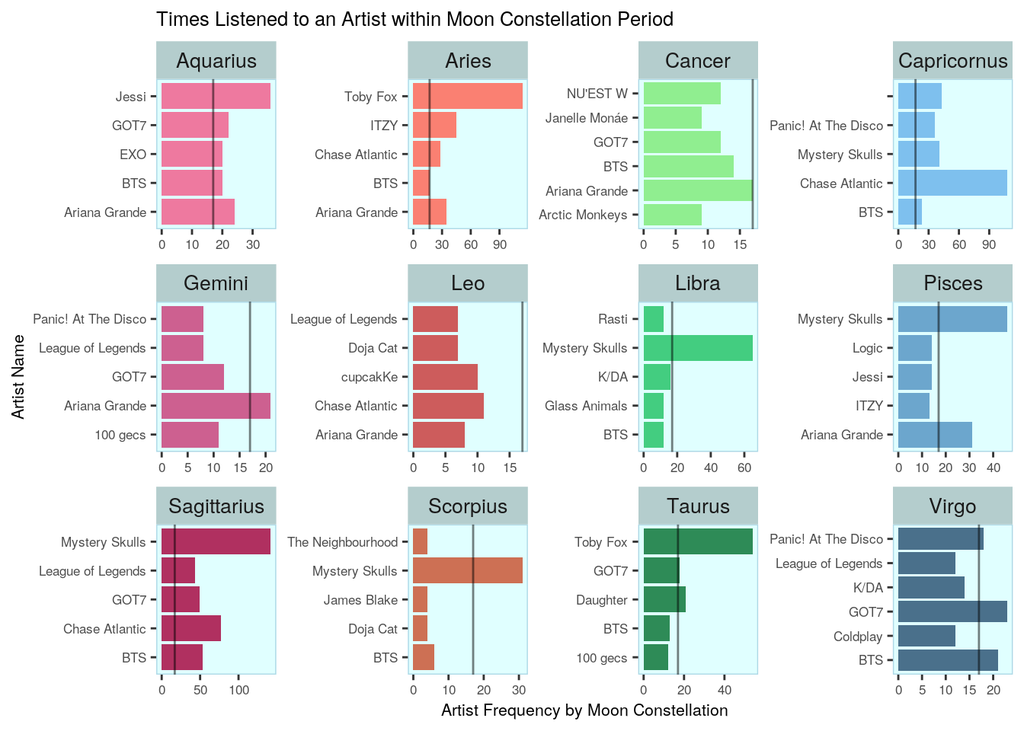

```r
MoonArtistFreq <- joined %>% na.omit() %>% group_by(MoonConstellation,
    artistName) %>% summarize(ArtistFreq = n()) %>% top_n(n = 5,
    wt = ArtistFreq)

ggplot(MoonArtistFreq, aes(x = artistName, y = ArtistFreq, fill = MoonConstellation)) +
    geom_errorbar(stat = "summary") + geom_bar(show.legend = F,
    stat = "summary") + geom_hline(alpha = 0.5, yintercept = median(MoonArtistFreq$ArtistFreq)) +
    facet_wrap(~MoonConstellation, scales = "free") + labs(x = NULL,
    y = "Artist Frequency by Moon Constellation") + coord_flip() +
    theme(panel.background = element_rect(fill = "lightcyan",
        colour = "lightblue"), panel.grid.major = element_blank(),
        panel.grid.minor = element_blank(), text = element_text(size = 8),
        strip.text = element_text(size = 10), strip.background = element_rect(fill = "lightcyan3")) +
    labs(x = "Artist Name", title = "Times Listened to an Artist within Moon Constellation Period") +
    scale_fill_manual(values = c("palevioletred2", "salmon",
        "lightgreen", "skyblue2", "hotpink3", "indianred", "seagreen3",
        "skyblue3", "maroon", "salmon3", "seagreen4", "skyblue4"))
```

This first plot depicts the top 5 artists for every Moon constellation period organized by the frequency in which they were played. The scaling of frequency is unique for every Zodiac sign, so a vertical line has been mapped to the median of the times an artist was played across all constellations in order to give an idea in which what constellations had more streaming activity compared to others. The Moon changes signs every two and a half days, which means this plot can give an idea as to the consistency in which my friends listens to the same artists if they appear across several zodiac signs or if a certain artist is listened to exclusively when the Moon was in a specific constellation. It can be seen that the highest frequency of streams grouped by Artist took place when the Moon was in Sagittarius, Aries, and Capricorn and the fewest frequency took place when the Moon was in Cancer and Leo. Excessive listening to the group Mystery Skulls took place while the Moon was in Sagittarius, Scorpio, and Libra. Toby Fox also appears to be a very popular artist for her when the Moon was in Aries and Taurus. Artists that my friend listened to consistently because they appear across at least half of the zodiac signs include BTS, GOT7, and Ariana Grande. Extra note: one of the artists does not appear in the Capricorn plot because their characters are in Japanese ( たかやん) and changing the base family font would not help the characters render.

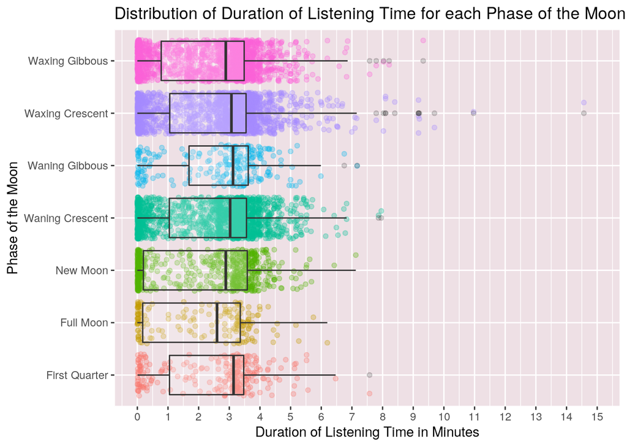

```r
ggplot(joined, aes(x = MoonPhase, y = minutesPlayed)) + geom_jitter(alpha = 0.3,
    aes(col = MoonPhase), show.legend = F) + geom_boxplot(alpha = 0.2,
    show.legend = F) + scale_y_continuous(limits = c(0, 15),
    name = "Duration of Listening Time in Minutes", breaks = seq(0,
        25, 1)) + labs(x = "Phase of the Moon", title = "Distribution of Duration of Listening Time for each Phase of the Moon") +
    coord_flip() + theme(panel.background = element_rect(fill = "lavenderblush2",
    colour = "white"))
```

The second plot is a boxplot distribution for duration of listening time in minutes per song at every Moon phase as well as a jitter plot that further shows overlapping minute values. By looking at this distribution, one can determine if there was a certain Moon phase in which more songs were skipped early on, if entire songs were allowed to play out, or if longer media was listened to. There are a few outliers not presented because they were listening times from 10 hour long sleeping/meditation ambient sounds. However, these especially high data points took place while the Moon phase was Waxing Gibbous and Crescent, and the jitter plot does indicate longer listening times at these phases. Outliers excluded, the longest song listening time appears to have taken place when the Moon was Waxing Crescent. The phase at which the shortest listening time occurred is difficult to determine as every moon phase had instances in which the song was skipped very quickly, but the New and Full Moon phases have the lowest as well as similar first quartiles. The Full Moon phase also has the lowest median listening duration, indicating that either very short media was listened to when the moon was full or songs were skipped pretty early on. Also, general streaming patterns from the density of the jitter plot at each phase can be determined. One would expect higher density of points within the waxing/waning phases, as they take place over the course of a few days rather than at one or two. However, the Waning Gibbous phase does appear to have a lower density of data when compared to the other intermediate phases and the New Moon phase has a slightly higher density of data when compared to the principal Full Moon and Quarter phases. One final thing I noticed is that my friend had no streaming history when the moon was in the Last Quarter! I was really nervous when I had seen it missing in the plot, but there were moon age values dropped when everything was joined meaning that there were repeated instances at the same time in the moon’s cycle in which my friend just didn’t use her Spotify.

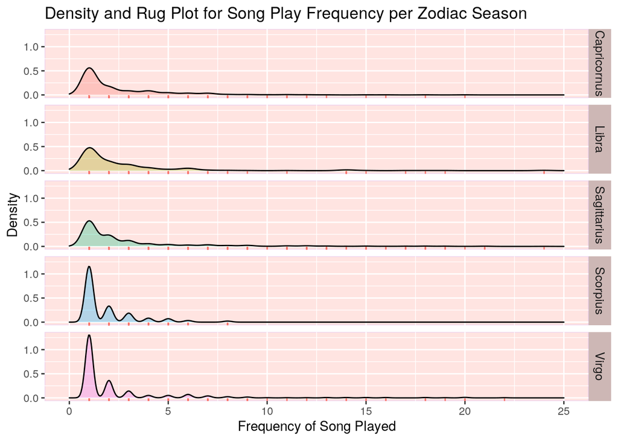

```r
SunSongFreq <- joined %>% na.omit() %>% group_by(SunConstellation,
    trackName) %>% summarize(SongFreq = n())

ggplot(SunSongFreq, aes(x = SongFreq, fill = SunConstellation)) +
    geom_rug(aes(color = "red", show.legend = F)) + geom_density(alpha = 0.3,
    show.legend = F) + facet_grid(SunConstellation ~ .) + scale_x_continuous(limits = c(0,
    25), name = "Frequency of Song Played") + guides(color = F) +
    ylab("Density") + ggtitle("Density and Rug Plot for Song Play Frequency per Zodiac Season") +
    theme(panel.background = element_rect(fill = "mistyrose1",
        colour = "thistle2"), strip.text = element_text(size = 10),
        strip.background = element_rect(fill = "mistyrose3"))
```

#### Concluding Remarks

There were a lot of ups and downs in doing this project! I’m very pleased that the data I acquired was pretty neat and joined nicely, but I had the most trouble with visualization because I was the most interested in categorical variables and you can only make so many graphs with those. A lot of conclusions drawn from the plots or summary statistics in general came from the fact that some moon phases and constellations had more data than others, so I would love to analyze these variables again over a longer time period to make sure that results aren’t skewed from some variable groups having a fewer number of observations versus others.